# R Notebook

## Problema 03

En este ejercicio visualizaremos el Teorema de Moivre-Laplace (TML). Para p=0.1 y A = {5, 10, 20, 50, 100, 500}, grafica lo siguiente:

1. Sobre la misma figura, grafica la función de masa g(x) de una distribución Binomial(n,p) y la función de densidad f(x) de una distribución Normal(np,npq), para todo ``n” en A. (i.e. presenta las seis figuras).
2. Haz lo mismo que en el inciso anterior, pero ahora para las funciones de distribución acumuladas de las binomiales y normales anteriores.
3. Cuál es la relación entre as figuras anteruires y el TML? Cambia el resultado si uno toma p=0.5 o p=0.9?

Para el inciso a): El siguiente código genera seis figurar para comparar la Distribución Binomial con su aproximación a la Normal para cada valor de nuestras n.

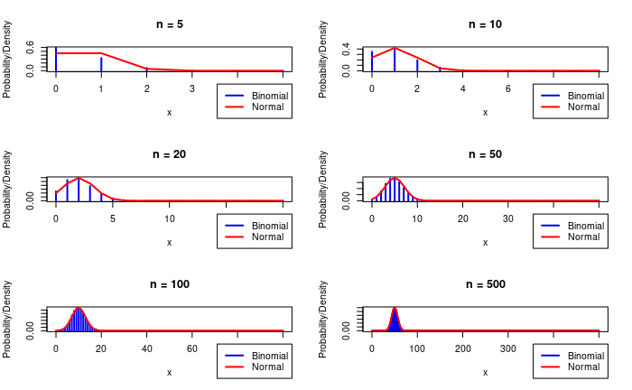

```r
# Parámetros
p <- 0.1
q <- 1 - p
A <- c(5, 10, 20, 50, 100, 500)

# Generar gráficos
par(mfrow=c(3, 2))  # Para organizar las 6 gráficas

for (n in A) {
  x <- 0:n
  binomial_vals <- dbinom(x, n, p)  # Función de masa binomial
  normal_vals <- dnorm(x, mean=n*p, sd=sqrt(n*p*q))  # Aproximación normal

  plot(x, binomial_vals, type="h", lwd=2, col="blue", ylim=c(0, max(binomial_vals, normal_vals)),
       main=paste("n =", n), ylab="Probability/Density", xlab="x")
  lines(x, normal_vals, col="red", lwd=2)  # Añadir la normal
  legend("topright", legend=c("Binomial", "Normal"), col=c("blue", "red"), lty=1, lwd=2, xpd=TRUE, inset=c(0, +1.5))
}
```

Podemos notar como a medida que n crece, la Binomial se aproxima cada vez mejor a la Normal. Esto ya está establecido de entrada por el TML.

A medida que n crece, la función de masa binomial se aproximará cada vez más a la curva normal, lo que visualiza el Teorema de Moivre-Laplace.

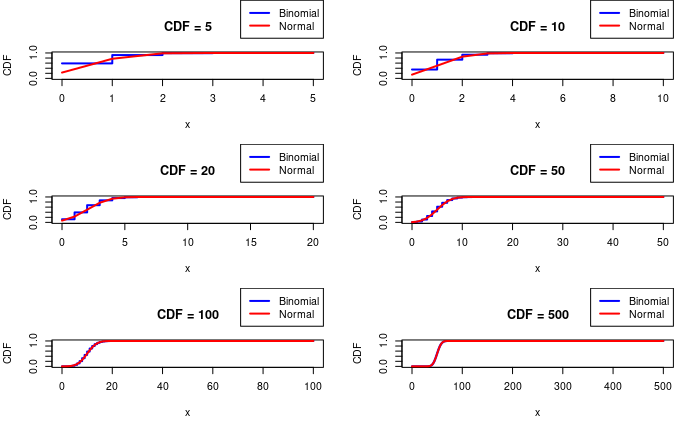

```r
# Parámetros
p <- 0.1
q <- 1 - p
A <- c(5, 10, 20, 50, 100, 500)

# Generar gráficos
par(mfrow=c(3, 2))  # Para organizar las 6 gráficas

for (n in A) {
  x <- 0:n
  binomial_cdf <- pbinom(x, n, p)  # Función de distribución acumulada binomial
  normal_cdf <- pnorm(x, mean=n*p, sd=sqrt(n*p*q))  # Aproximación normal

  plot(x, binomial_cdf, type="s", lwd=2, col="blue", ylim=c(0, 1),
       main=paste("CDF =", n), ylab="CDF", xlab="x")
  lines(x, normal_cdf, col="red", lwd=2)  # Añadir la CDF normal
  legend("bottomright", legend=c("Binomial", "Normal"), col=c("blue", "red"), lty=1, lwd=2, xpd=TRUE, inset=c(0, +1.5))
}
```

A medida que n crece, la CDF binomial se aproxima cada vez más a la CDF normal. Esto ilustra gráficamente el Teorema de Moivre-Laplace, que dice que la binomial converge a la normal conforme n aumenta.

##### PARA P=0.5

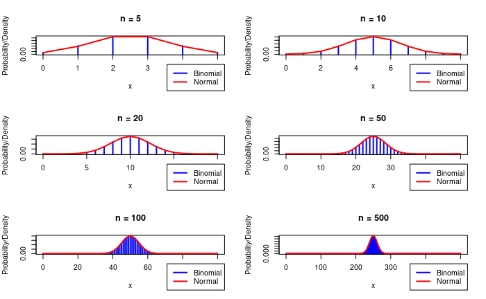

```r
# Parámetros
p <- 0.5
q <- 1 - p
A <- c(5, 10, 20, 50, 100, 500)

# Generar gráficos
par(mfrow=c(3, 2))  # Para organizar las 6 gráficas

for (n in A) {
  x <- 0:n
  binomial_vals <- dbinom(x, n, p)  # Función de masa binomial
  normal_vals <- dnorm(x, mean=n*p, sd=sqrt(n*p*q))  # Aproximación normal

  plot(x, binomial_vals, type="h", lwd=2, col="blue", ylim=c(0, max(binomial_vals, normal_vals)),
       main=paste("n =", n), ylab="Probability/Density", xlab="x")
  lines(x, normal_vals, col="red", lwd=2)  # Añadir la normal
  legend("topright", legend=c("Binomial", "Normal"), col=c("blue", "red"), lty=1, lwd=2, xpd=TRUE, inset=c(0, +1.5))
}
```

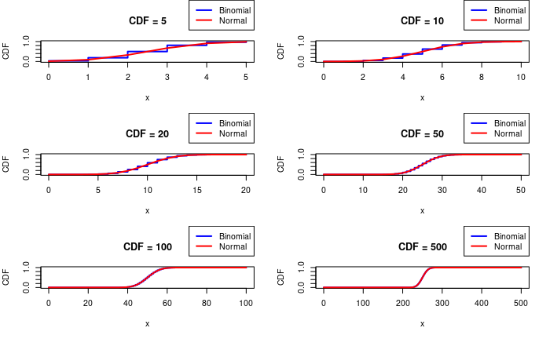

```r
# Parámetros
p <- 0.5
q <- 1 - p
A <- c(5, 10, 20, 50, 100, 500)

# Generar gráficos
par(mfrow=c(3, 2))  # Para organizar las 6 gráficas

for (n in A) {
  x <- 0:n
  binomial_cdf <- pbinom(x, n, p)  # Función de distribución acumulada binomial
  normal_cdf <- pnorm(x, mean=n*p, sd=sqrt(n*p*q))  # Aproximación normal

  plot(x, binomial_cdf, type="s", lwd=2, col="blue", ylim=c(0, 1),
       main=paste("CDF =", n), ylab="CDF", xlab="x")
  lines(x, normal_cdf, col="red", lwd=2)  # Añadir la CDF normal
  legend("bottomright", legend=c("Binomial", "Normal"), col=c("blue", "red"), lty=1, lwd=2, xpd=TRUE, inset=c(0, +1.5))
}
```

##### PARA P=0.9

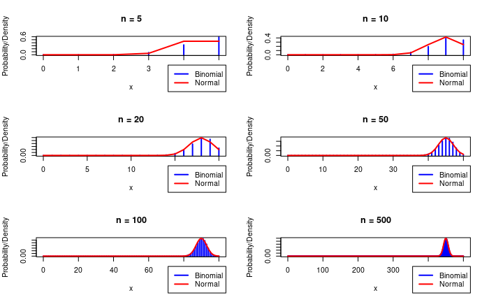

```r
# Parámetros
p <- 0.9
q <- 1 - p
A <- c(5, 10, 20, 50, 100, 500)

# Generar gráficos
par(mfrow=c(3, 2))  # Para organizar las 6 gráficas

for (n in A) {
  x <- 0:n
  binomial_vals <- dbinom(x, n, p)  # Función de masa binomial
  normal_vals <- dnorm(x, mean=n*p, sd=sqrt(n*p*q))  # Aproximación normal

  plot(x, binomial_vals, type="h", lwd=2, col="blue", ylim=c(0, max(binomial_vals, normal_vals)),
       main=paste("n =", n), ylab="Probability/Density", xlab="x")
  lines(x, normal_vals, col="red", lwd=2)  # Añadir la normal
  legend("topright", legend=c("Binomial", "Normal"), col=c("blue", "red"), lty=1, lwd=2, xpd=TRUE, inset=c(0, +1.5))
}
```

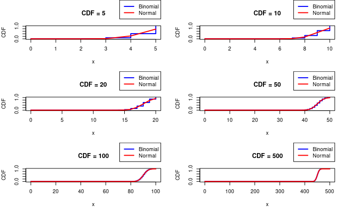

```r
# Parámetros
p <- 0.9
q <- 1 - p
A <- c(5, 10, 20, 50, 100, 500)

# Generar gráficos
par(mfrow=c(3, 2))  # Para organizar las 6 gráficas

for (n in A) {
  x <- 0:n
  binomial_cdf <- pbinom(x, n, p)  # Función de distribución acumulada binomial
  normal_cdf <- pnorm(x, mean=n*p, sd=sqrt(n*p*q))  # Aproximación normal

  plot(x, binomial_cdf, type="s", lwd=2, col="blue", ylim=c(0, 1),
       main=paste("CDF =", n), ylab="CDF", xlab="x")
  lines(x, normal_cdf, col="red", lwd=2)  # Añadir la CDF normal
  legend("bottomright", legend=c("Binomial", "Normal"), col=c("blue", "red"), lty=1, lwd=2, xpd=TRUE, inset=c(0, +1.5))
}
```